# IDEAS-QA4EO: @qa4eoCalVal Twitter dashboard

Updated: 2023-02-14

## Visit us at https://twitter.com/qa4eoCalVal

[figure not shown]

## Number of tweets

```
## [1] "Total number of tweets = 245"
```

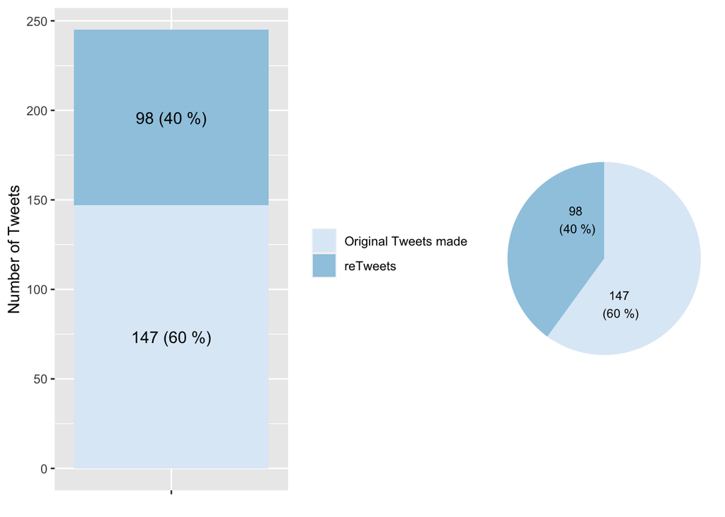

## Frequency of releases

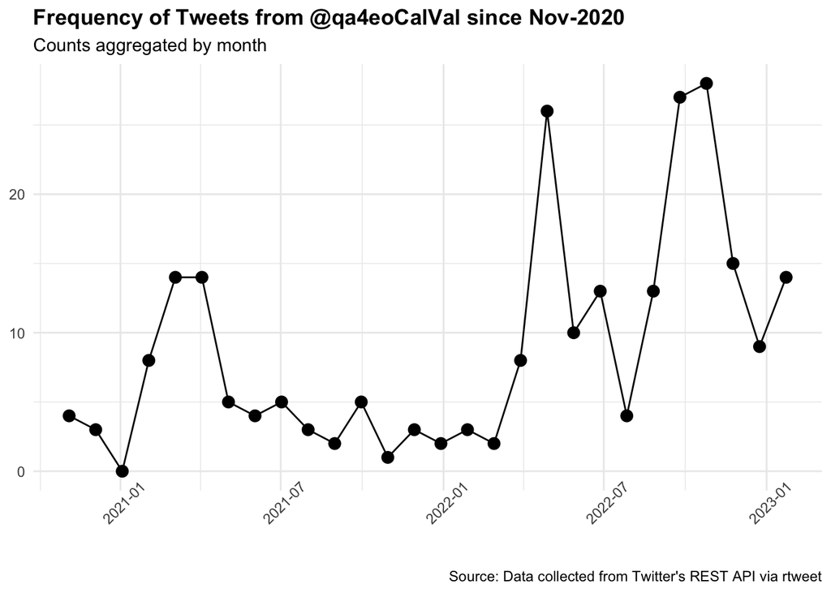

## Last tweet we posted

```
## [1] "On  2023-02-13 10:46:04"
```

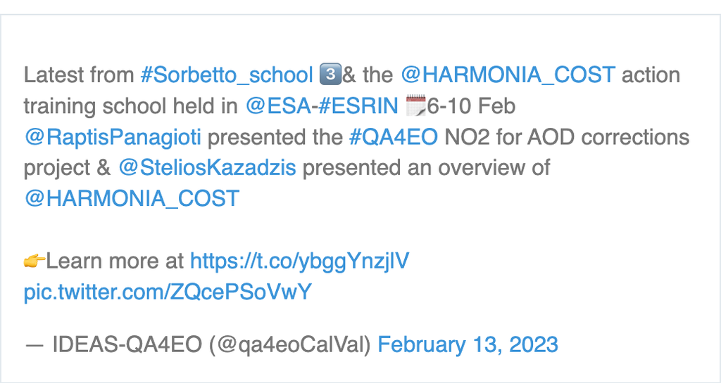

## Relevant stats & figures

```
## [1] "Number of Followers = 163"
```

```
## [1] "Total number of Likes received = 956"
```

```
## [1] "Total number of Retweets we had = 251"
```

### Main sources of our retweets

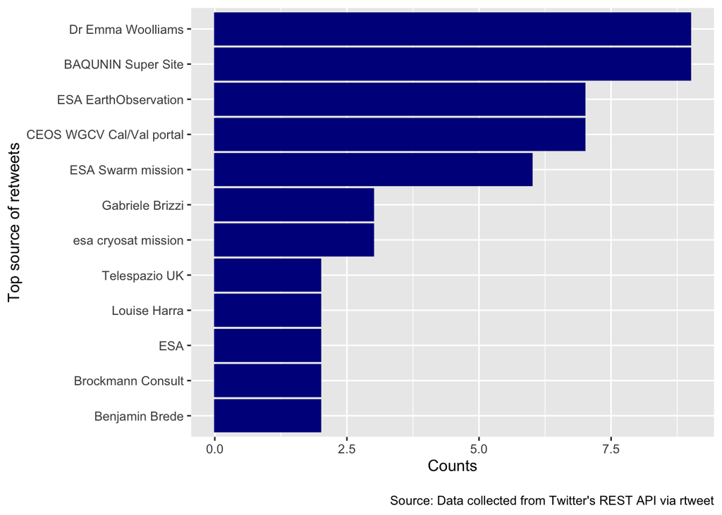

### Most Liked tweet(s)

```
## [1] "Most Liked tweet ( 18 ) =>>>  📢The IDEAS-#QA4EO service started in Nov. 2019 to boost data quality of @ESA_EO operational missions and methodological innovation in #CalVal. It has grown to over 35 institutes and 51 R&amp;D WPs during Phase 1.🆕A new contractual phase has now started for a 2.5…
## [2] "Most Liked tweet ( 18 ) =>>>  #LPS22 - The poster session is in full swing.\nStill 30 minutes to meet @AlexDiBella at board n.350 and ask him details on the #CryoSat processing for Inland waters.\n@esa_cryosat  @ESA_EO   IDEAS-#QA4EO https://t.co/b1vupnHurK"
## [3] "Most Liked tweet ( 18 ) =>>>  The IDEAS-#QA4EO #calval workshop has just ended. Several recommendations and new ideas were collected for the evolution of the contract. \nWe are one step closer to Phase 2. \nThank you to all participants and presenters ! https://t.co/WuYAnH33Wt"
```

> 📢The IDEAS-[#QA4EO](https://twitter.com/hashtag/QA4EO?src=hash&ref_src=twsrc%5Etfw) service started in Nov. 2019 to boost data quality of [@ESA_EO](https://twitter.com/ESA_EO?ref_src=twsrc%5Etfw) operational missions and methodological innovation in [#CalVal](https://twitter.com/hashtag/CalVal?src=hash&ref_src=twsrc%5Etfw). It has grown to over 35 institutes and 51 R&D WPs during Phase 1.🆕A new contractual phase has now started for a 2.5 years extension.🤝 [pic.twitter.com/QLclwbW80i](https://t.co/QLclwbW80i)

> — IDEAS-QA4EO (@qa4eoCalVal) [June 21, 2022](https://twitter.com/qa4eoCalVal/status/1539147166530273281?ref_src=twsrc%5Etfw)

> [#LPS22](https://twitter.com/hashtag/LPS22?src=hash&ref_src=twsrc%5Etfw) - The poster session is in full swing.  
> Still 30 minutes to meet [@AlexDiBella](https://twitter.com/AlexDiBella?ref_src=twsrc%5Etfw) at board n.350 and ask him details on the [#CryoSat](https://twitter.com/hashtag/CryoSat?src=hash&ref_src=twsrc%5Etfw) processing for Inland waters.[@esa_cryosat](https://twitter.com/esa_cryosat?ref_src=twsrc%5Etfw) [@ESA_EO](https://twitter.com/ESA_EO?ref_src=twsrc%5Etfw) IDEAS-[#QA4EO](https://twitter.com/hashtag/QA4EO?src=hash&ref_src=twsrc%5Etfw) [pic.twitter.com/b1vupnHurK](https://t.co/b1vupnHurK)

> — IDEAS-QA4EO (@qa4eoCalVal) [May 26, 2022](https://twitter.com/qa4eoCalVal/status/1529863367518785538?ref_src=twsrc%5Etfw)

> The IDEAS-[#QA4EO](https://twitter.com/hashtag/QA4EO?src=hash&ref_src=twsrc%5Etfw) [#calval](https://twitter.com/hashtag/calval?src=hash&ref_src=twsrc%5Etfw) workshop has just ended. Several recommendations and new ideas were collected for the evolution of the contract.  
> We are one step closer to Phase 2.  
> Thank you to all participants and presenters ! [pic.twitter.com/WuYAnH33Wt](https://t.co/WuYAnH33Wt)

> — IDEAS-QA4EO (@qa4eoCalVal) [April 1, 2022](https://twitter.com/qa4eoCalVal/status/1509904339418165255?ref_src=twsrc%5Etfw)

### Most retweeted tweet(s)

```
## [1] "Most Retweeted ( 8 ) =>>>  ‼️Call open for abstracts for #LPVE (Land Product Validation &amp; Evolution) 2023 workshop‼️\n\nThe workshop will be held at #ESRIN 📅12-14 Jun for #CalVal experts\n➡️More at https://t.co/iSVje3PM77\n➡️Get your abstracts in by 20 March 2023\n👉https://t.co/xcgzMIioK…
```

> ‼️Call open for abstracts for [#LPVE](https://twitter.com/hashtag/LPVE?src=hash&ref_src=twsrc%5Etfw) (Land Product Validation & Evolution) 2023 workshop‼️  
> The workshop will be held at [#ESRIN](https://twitter.com/hashtag/ESRIN?src=hash&ref_src=twsrc%5Etfw) 📅12-14 Jun for [#CalVal](https://twitter.com/hashtag/CalVal?src=hash&ref_src=twsrc%5Etfw) experts  
> ➡️More at https://t.co/iSVje3PM77  
> ➡️Get your abstracts in by 20 March 2023  
> 👉https://t.co/xcgzMIioKq[#LPVE2023](https://twitter.com/hashtag/LPVE2023?src=hash&ref_src=twsrc%5Etfw) [@ESA_EO](https://twitter.com/ESA_EO?ref_src=twsrc%5Etfw) [pic.twitter.com/ZOAypbxV1i](https://t.co/ZOAypbxV1i)

> — IDEAS-QA4EO (@qa4eoCalVal) [January 23, 2023](https://twitter.com/qa4eoCalVal/status/1617521842457284612?ref_src=twsrc%5Etfw)

## Hashtag analysis

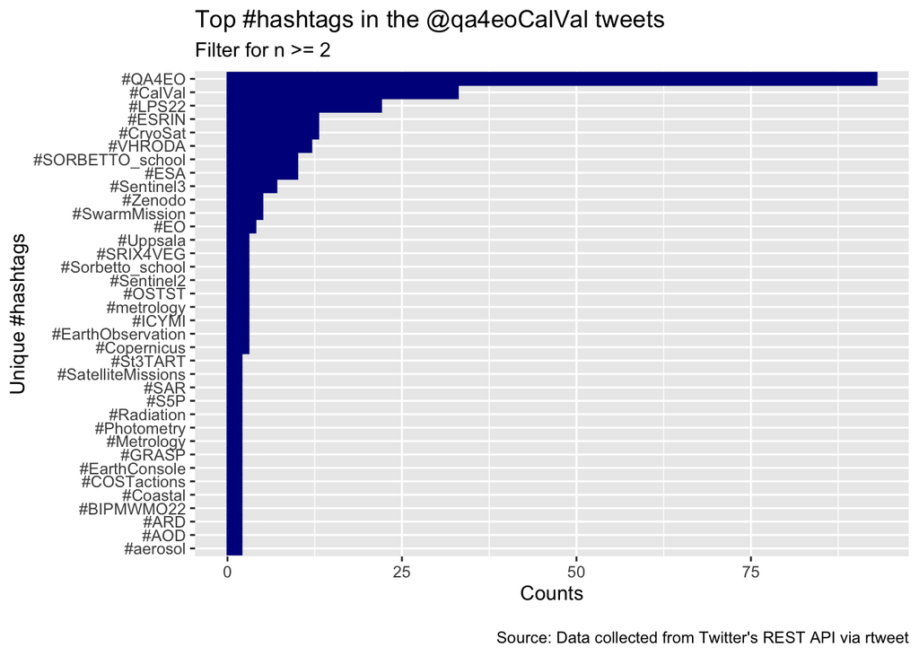

## Word Cloud of most frequently used hashtags

Here removed #QA4EO occurrences

[interactive chart not shown]

## Word usage

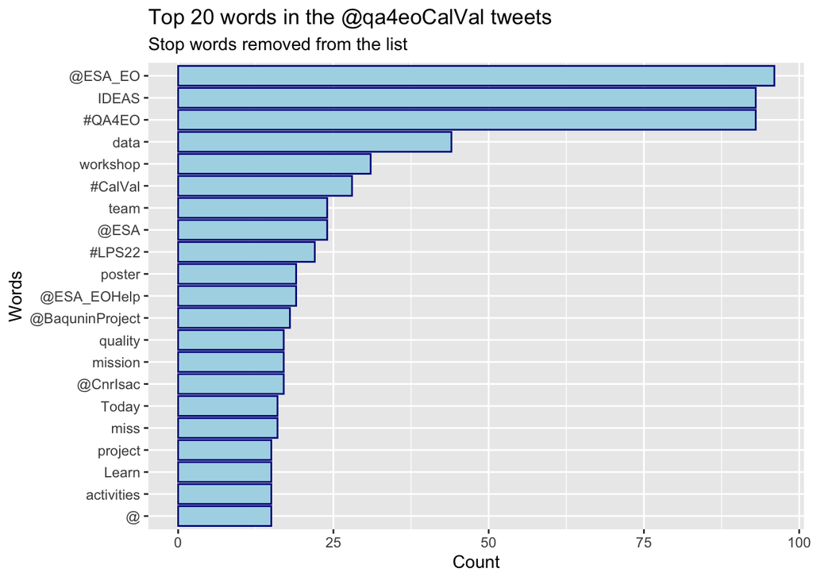

## Mentions

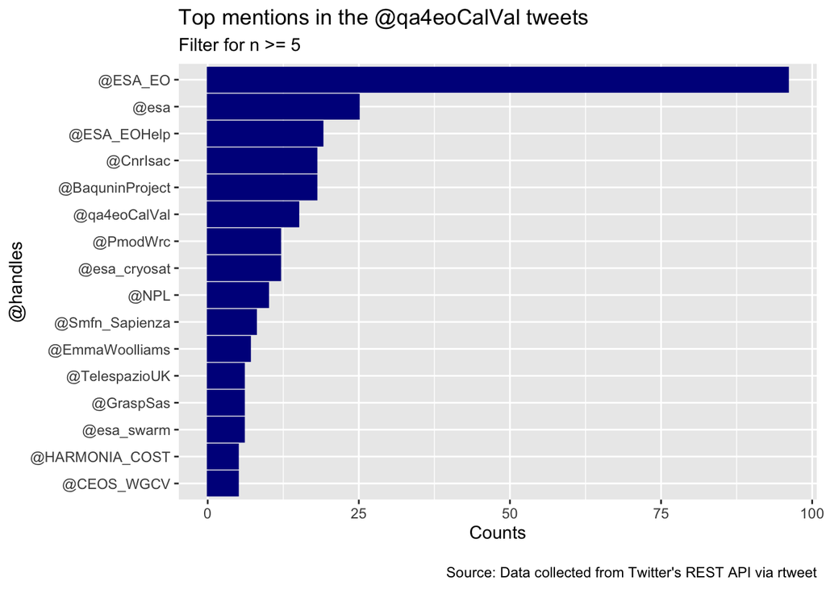

## Top used emojis

```
##
## 👉  ➡️ 📢  🛰️  ☀️ 📅  3️⃣ 📍 👇 ⚡ ✅ 👏  ‼️ 🇸🇪 🌍 📌 🔗  1️⃣ 🆕  🗓️
## 41 38 31 23 15 13 11  9  8  7  7  7  6  6  6  6  6  6  6  5
```

## Monitor trends for hashtags

Searching for tweets with specific hashtags. Search limited over the past 6-9 days.

#QA4EO

```
## [1] "HARMONIA_COST"   "SteliosKazadzis" "BaquninProject"  "qa4eoCalVal"
## [1] "2023-02-13 11:32:39 CET" "2023-02-13 10:56:01 CET"
## [3] "2023-02-13 10:53:05 CET" "2023-02-13 10:46:04 CET"
```

```
## [1] "RT @qa4eoCalVal: Latest from #Sorbetto_school 3️⃣&amp; the @HARMONIA_COST action training school held in @ESA-#ESRIN 🗓️6-10 Feb  \n\n@RaptisPanag…"
## [2] "RT @qa4eoCalVal: Latest from #Sorbetto_school 3️⃣&amp; the @HARMONIA_COST action training school held in @ESA-#ESRIN 🗓️6-10 Feb  \n\n@RaptisPanag…"
## [3] "RT @qa4eoCalVal: Latest from #Sorbetto_school 3️⃣&amp; the @HARMONIA_COST action training school held in @ESA-#ESRIN 🗓️6-10 Feb  \n\n@RaptisPanag…"
## [4] "Latest from #Sorbetto_school 3️⃣&amp; the @HARMONIA_COST action training school held in @ESA-#ESRIN 🗓️6-10 Feb  \n\n@RaptisPanagioti presented the #QA4EO NO2 for AOD corrections project &amp; @SteliosKazadzis  presented an overview of @HARMONIA_COST\n\n👉Learn more at https://t.co/ybggYnzjlV …
```

#calval

```
## [1] "BaquninProject" "qa4eoCalVal"
## [1] "2023-02-08 19:07:32 CET" "2023-02-08 17:34:34 CET"
```

```
## [1] "RT @qa4eoCalVal: ☀️Today at Day 3️⃣ of #SORBETTO_school 3  at @ESA-#ESRIN interesting presentation and discussion on: \n✅#SatelliteRemoteSen…"
## [2] "☀️Today at Day 3️⃣ of #SORBETTO_school 3  at @ESA-#ESRIN interesting presentation and discussion on: \n✅#SatelliteRemoteSensing\n✅#SatelliteMissions\n✅#CalVal activities\n✅#Airquality, #Aeorosol and #GreenhouseGas observations with #Sentinel5P\n \n➡️Programme https://t.co/2rmcH2gwuQ https://…
```

#BAQUNIN

```
## [1] "CEOS_WGCV"
## [1] "2023-02-08 14:56:52 CET"
```

```
## [1] "RT @BaquninProject: #BAQUNIN staff busy aligning a skycam! 🧭Look Rome sky on @BaquninProject website! ☀️🌤️🌦️https://t.co/UCuqASTGNp https:/…"
```

## Twitter account evolution

for tweets and followers

|  | Date | Posts | Followers |
| --- | --- | --- | --- |
| 66 | 2022-09-27 | 154 | 135 |
| 67 | 2022-09-30 | 156 | 135 |
| 68 | 2022-10-18 | 174 | 143 |
| 69 | 2022-10-24 | 179 | 145 |
| 70 | 2022-10-26 | 180 | 145 |
| 71 | 2022-10-31 | 181 | 145 |
| 72 | 2022-11-08 | 194 | 149 |
| 73 | 2022-11-09 | 199 | 149 |
| 74 | 2022-11-10 | 203 | 149 |
| 75 | 2022-11-15 | 207 | 150 |
| 76 | 2022-12-06 | 216 | 151 |
| 77 | 2022-12-12 | 219 | 151 |
| 78 | 2022-12-22 | 221 | 151 |
| 79 | 2023-01-02 | 222 | 152 |
| 80 | 2023-01-18 | 231 | 158 |
| 81 | 2023-01-25 | 232 | 158 |
| 82 | 2023-01-26 | 232 | 160 |
| 83 | 2023-01-29 | 234 | 161 |
| 84 | 2023-02-02 | 235 | 161 |
| 85 | 2023-02-13 | 245 | 163 |

```
##          Date Posts Followers
## 1  2021-04-14    38        56
## 2  2021-05-06    44        62
## 3  2021-06-05    48        68
## 4  2021-07-06    52        72
## 5  2021-08-30    60        76
## 6  2021-09-15    60        78
## 7  2021-10-05    64        78
## 8  2021-10-19    65        77
## 9  2021-10-21    66        77
## 10 2021-10-25    66        78
## 11 2021-10-29    67        78
## 12 2021-11-16    67        79
## 13 2021-11-23    68        79
## 14 2021-12-02    68        80
## 15 2021-12-07    69        80
## 16 2021-12-17    70        80
## 17 2021-12-21    71        80
## 18 2022-01-18    72        80
## 19 2022-01-27    73        81
## 20 2022-01-31    73        82
```

```
##          Date Posts Followers
## 81 2023-01-25   232       158
## 82 2023-01-26   232       160
## 83 2023-01-29   234       161
## 84 2023-02-02   235       161
## 85 2023-02-13   245       163
```

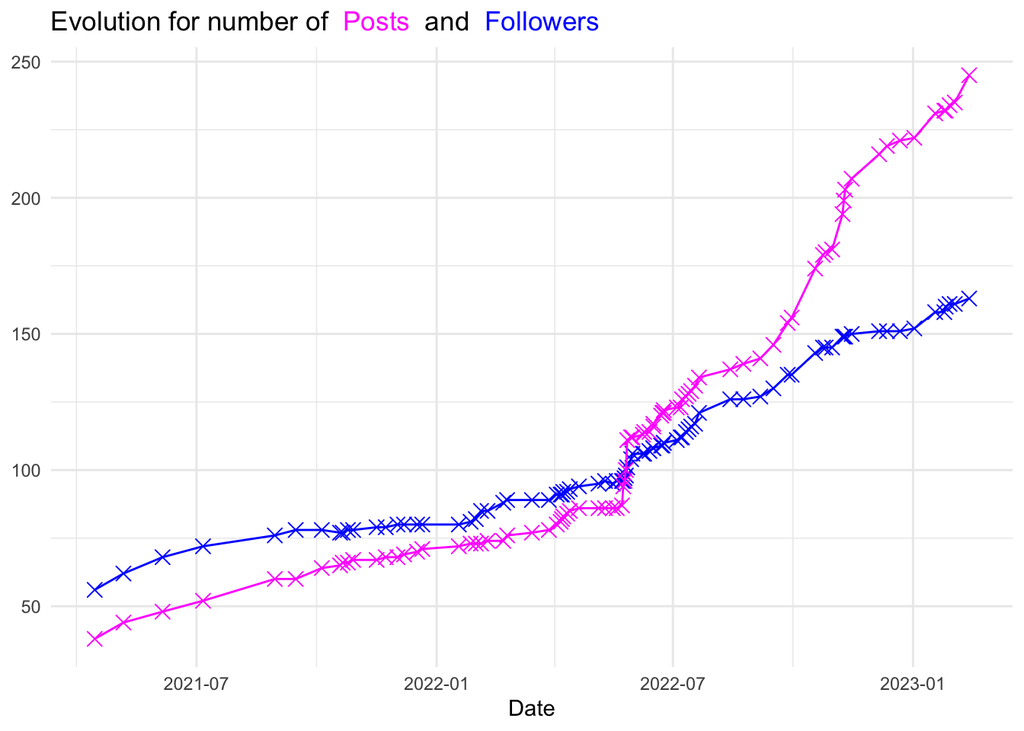

## Likes we gave

[interactive chart not shown]

## New followers

[interactive chart not shown]